# Lab 7: Spatial Autocorrelation & Spatial Weights

# Introduction

The data that we’ll be working with for this lab comes from the open [POLITY IV dataset](http://www.systemicpeace.org/polity/polity4.htm). The Polity data series is a widely used data series in political science research. The latest version, Polity IV, contains coded annual information on the level of democracy for all independent states with greater than, $500,000$ total population and covers the years $1800–2014$. Polity’s conclusions about a state’s level of democracy are based on an evaluation of that state’s elections for competitiveness and openness, the nature of political participation in general, and the extent of checks on executive authority. For each year and country, a “Polity Score” is determined which ranges from -10 to +10, with -10 to -6 corresponding to autocracies, -5 to 5 corresponding to anocracies, and 6 to 10 to democracies. There are certainly limitations to using such a score to quantify ‘democraticness’, but for the purposes of this lab, this dataset will do just fine!

The primary goal of this lab is an initial exploration of the spatial analysis tools available in `R`. For starters, we’ll do some basic choropleth mapping, and then we’ll progress to developing spatial weights matrices and computing some spatial autocorrelation statistics. The actual lab exercise requires you to do a lot of exploration on your own, but this lab prep should get you started on your way! To start, we’re going to be relying on a number of spatial (and aspatial) packages to get our work done in `R`:

```r
library(maptools) # Tools for mapping
library(rgdal)    # Reading and writing geographic data
library(stringr)  # Working with strings
library(ggplot2)  # Plotting and stuff
library(ggthemes) # Some nice themes, including the theme_map
library(plyr)     # The join fuction and others
```

# Mapping

What if you have some data you’d like to merge with a map? Let’s open a world map Shapefile and use it to get mapping! First, we’ll read in our geographic data using the `OGR` geospatial library (Google `OGR` if you want to learn more). We’re also going to convert names to lower-case to make joining easier later on. This isn’t something you’ll always have to do…

```r
map = readOGR("data/world.shp", "world")
names(map) = str_to_lower(names(map))  # Convert names to lowercase
summary(map)
```

```
## Object of class SpatialPolygonsDataFrame
## Coordinates:
##    min      max
## x -180 180.0000
## y  -90  83.6236
## Is projected: NA
## proj4string : [NA]
## Data attributes:
##      sp_id            country      map_ccode           ccode
##  1005667:  1   Afghanistan:  1   Min.   : 206923   Min.   :  2.0
##  1059087:  1   Albania    :  1   1st Qu.: 206992   1st Qu.:316.0
##  1063368:  1   Algeria    :  1   Median : 207045   Median :452.0
##  1063498:  1   Angola     :  1   Mean   : 230673   Mean   :460.8
##  206923 :  1   Antarctica :  1   3rd Qu.: 207117   3rd Qu.:660.0
##  206924 :  1   Argentina  :  1   Max.   :1063498   Max.   :950.0
##  (Other):180   (Other)    :180                     NA's   :21
```

This is a `SpatialPolygonsDataFrame`, which is a spatial variant of a `data.frame`. It has a bunch of generic functions specified for it, including things like `summary()` above, and even a base `plot()` function (though the base plot isn’t that pretty):

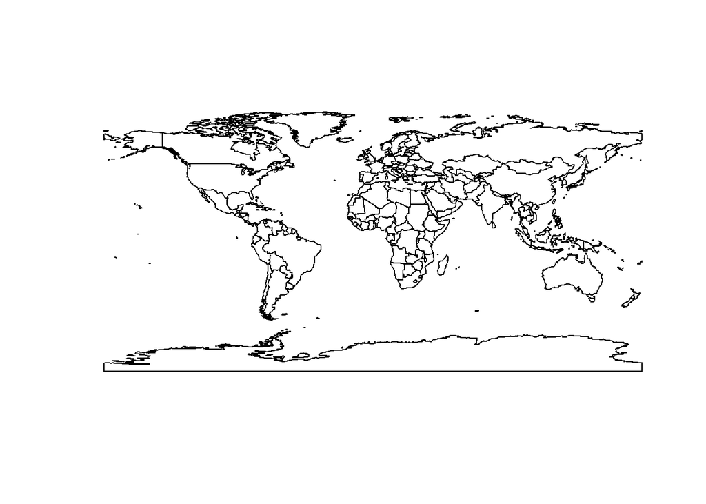

```r
plot(map)
```

Here is a CSV file that contains the latest Polity data. Normally this comes as an excel file, but since excel is a pain in `R` I’ve done the conversion for you:

```r
polity = read.csv("data/p4v2014.csv")
names(polity)
```

```
##  [1] "cyear"    "ccode"    "scode"    "country"  "year"     "flag"
##  [7] "fragment" "democ"    "autoc"    "polity"   "polity2"  "durable"
## [13] "xrreg"    "xrcomp"   "xropen"   "xconst"   "parreg"   "parcomp"
## [19] "exrec"    "exconst"  "polcomp"  "prior"    "emonth"   "eday"
## [25] "eyear"    "eprec"    "interim"  "bmonth"   "bday"     "byear"
## [31] "bprec"    "post"     "change"   "d4"       "sf"       "regtrans"
```

We’ll start by subsetting for the year 2010, which is a year with particularly good coverage:

```r
polity = subset(polity, year == 2010)
```

Since there are some ‘missing’ values here, we need to ‘drop’ (set to `NA`) some cases where the Polity variable isn’t in the range -10 to +10:

```r
polity$polity[polity$polity < -10] = NA
```

We can now ‘join’ the Polity data to our global ‘map’ using the `ccode` variable that they have in common. The `plyr` library has a nice function called `join` that does just this, and it does it in a way that is condusive to joining tabular data to spatial data:

```r
# We have to be careful here, we're (re)assigning the tabular data for our global map
map@data = join(map@data, polity, by="ccode")
```

At this point, you can save this joined data to a new shapefile (if you want):

```r
map$country = NULL  # There are duplicates in this column that muck things up...
writeOGR(map, 'data/polity_iv_map.shp', layer="polity_iv_map", driver="ESRI Shapefile")
```

### Let’s make a map

We can start plotting the Polity scores right away using the ‘default’ spatial plotting function. This is `spplot` from the `sp` package, which is the main package for working with geographic data. However, we can do a lot nicer job if we use ggplot!

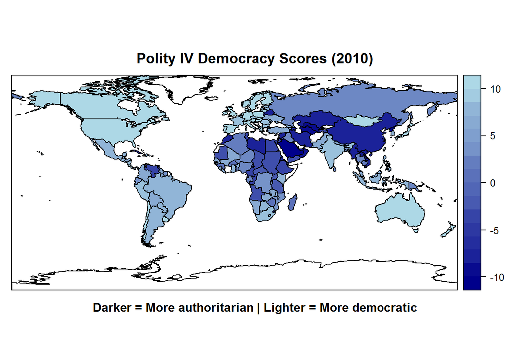

```r
dem.palette = colorRampPalette(c("darkblue", "lightblue"), space = "rgb")
spplot(map, "polity", col.regions=dem.palette(20),
       main="Polity IV Democracy Scores (2010)",
       sub="Darker = More authoritarian | Lighter = More democratic")
```

So let’s try that again using `ggplot`. It requires a little extra work up front, but the results can be quite a bit nicer… In particular, since `ggplot` expects everything to be a `data.frame`, we need to use the `fortify` function to convert the spatial data into a regular `data.frame`:

```r
# This is a bit of a 'hack' to match up the attributes to the polygons
# In some cases, you might not need to do this, but sometimes its required :(
map@data$id <- as.numeric(rownames(map@data))-1

class(map)  # Not a regular data.frame...
```

```
## [1] "SpatialPolygonsDataFrame"
## attr(,"package")
## [1] "sp"
```

```r
new_map = fortify(map)
class(new_map)  # Now we have a regular data.frame!
```

```
## [1] "data.frame"
```

If you look at the `head()` of the `new_map` object, you’ll notice all the attribute information has been dropped. Again, a perculiarity of the `fortify` function. We can put things back with:

```r
new_map = join(new_map, map@data, by="id")
```

Now plotting is just like we would for any other `ggplot`, with two key requirements:

1. `x` and `y` have to be `long` and `lat`
2. we need to use the `group` variable that `fority` has automagically created for us

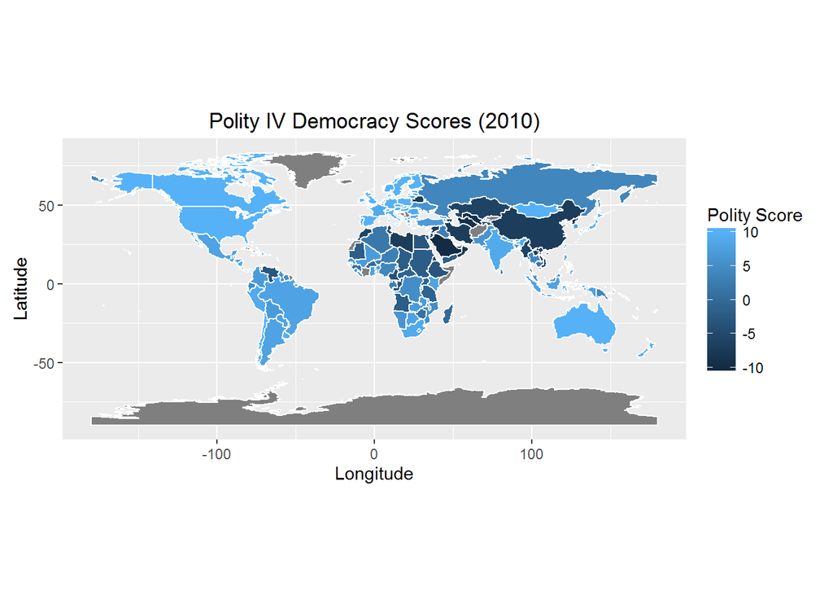

```r
p = ggplot(data=new_map, aes(x=long, y=lat, group=group))

p = p + geom_polygon(aes(fill=polity)) +
        geom_path(color="white") +
        coord_equal() +
        scale_fill_continuous("Polity Score") +
        labs(x="Longitude", y="Latitude",
             title="Polity IV Democracy Scores (2010)")
p
```

Even better, why don’t we project this using a area-preserving projection; one of my favorites is ‘Mollweid’:

```r
# First, let's create a bounding box to plot as the background...
outline = bbox(map)  # This grabs the bounding box of the overall map area
# However, we want a 'bounding box' of the whole globe:
outline = data.frame(xmin=-180, xmax=180, ymin=-90, ymax=90)
```

Next, we’ll plot with the Mollweide projection:

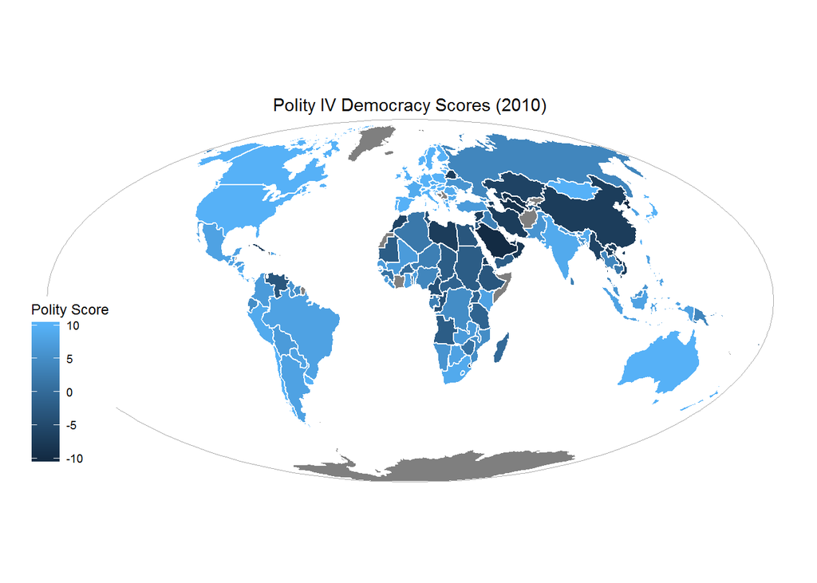

```r
p + geom_rect(data=outline, aes(xmin=xmin, xmax=xmax,
                                ymin=ymin, ymax=ymax,
                                x=NULL, y=NULL, group=NULL),
              color="darkgrey", fill="transparent", size=0.3) +
    coord_map("mollweide") +
    theme_map()
```

# Spatial Weights

In this section, we’re going to start building various spatial weights definitions, and calculate the associated spatial weights matrices. This is a neccesary step in quantifying spatial autocorrelation: defining what is meant by ‘close’ or ‘neighbor’.

## Contiguity

First, we’ll start by defining ‘neighbors’ as those countries that share boundaries… this is called contiguity weights or contiguity neighbors. In this sense, countries that shared a boundary are considered ‘neighbors’. Note that for this exercise, we’re working with geographic (lat/long) data. We’ll need to `spdep` package to compute weights matrices:

```r
library(spdep)
# Contiguity Neighbors (no snap distance)
W_cont = poly2nb(map, queen=TRUE)  # Google queen contiguity to learn what this means...
# Don't forget to try `?nb2list2` to figure out what's going on here...
W_cont_mat = nb2listw(W_cont, style="W", zero.policy=TRUE)

# Contiguity Neighbors (snap distance = 5 arc degrees)
W_cont_s = poly2nb(map, queen=TRUE, snap=5)
W_cont_s_mat = nb2listw(W_cont_s, style="W", zero.policy=TRUE)
```

Now we can plot the connections (neighbor relations) using base `R` graphics. Since we’ll want to plot connections based on the centroids of the polygons, we’ll grab this information using the following snippet of code:

```r
map_crd = coordinates(map)  # Get reference to map (centroid) coordinates
```

And now we plot!

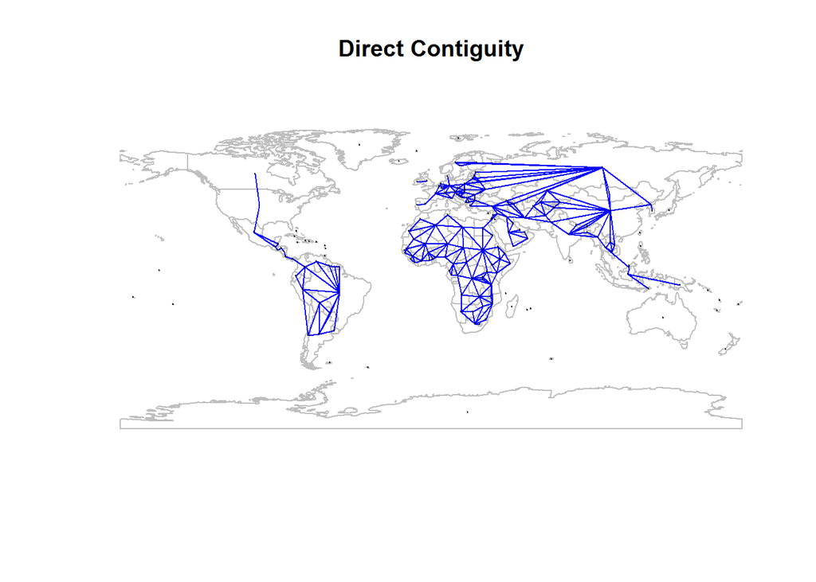

```r
plot(map, border="grey")
plot(W_cont_mat, coords=map_crd, pch=19, cex=0.1, col="blue", add=TRUE)
title("Direct Contiguity")
```

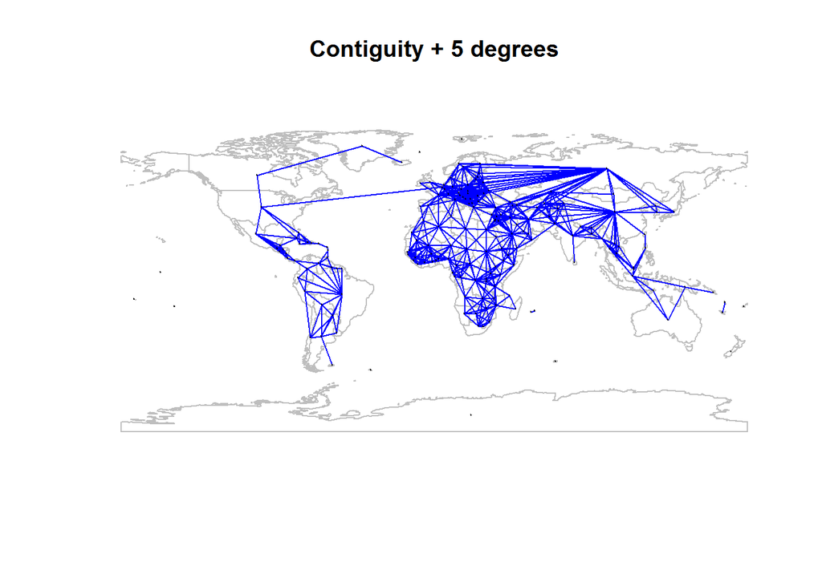

```r
plot(map, border="grey")
plot(W_cont_s_mat, coords=map_crd, pch=19, cex=0.1, col="blue", add=TRUE)
title("Contiguity + 5 degrees")
```

## Distance-based

Next, we’ll load some data on the various capital cities of the world. We’re doing this so that we can explore alternative definitions of ‘close’. For instance, we’re going to compute spatial weights matrices for both the centroids of the countries *and* their associated capital cities and compare the differences. Normally, it wouldn’t be a good idea to compute distances in geographic coordinate space, but for the purposes of a demo, I think we’re ok… When doing your own spatial autocorrelation analysis, it is important to think serious about what exactly close or nearby means!

```r
cities = read.csv("data/global_cities.csv")

# Join the associated Polity attributes
cities = join(cities, map@data, by="ccode")
```

Now we’ll ‘upgrade’ the `cities` `data.frame` into a `SpatialPointsDataFrame`:

```r
coordinates(cities) = c("long", "lat")
city_crd = coordinates(cities)  # Get reference to cities coordinates
```

### K-nearest neighbors

Our first distance-based definition of ‘close’ will be based on a specified number of near neighbors. We start with $k = 1$, so that we only consider the closest country to be a ‘neighbor’. Normally this wouldn’t be useful for spatial analysis (we need multiple neighbors), but its useful to explore:

```r
# Centroids
W_knn1 = knn2nb(knearneigh(map_crd, k=1))
W_knn1_mat = nb2listw(W_knn1)

# Capitals
W_knn1_2 = knn2nb(knearneigh(city_crd, k=1))
W_knn1_mat_2 = nb2listw(W_knn1_2)
```

Plot the connections!

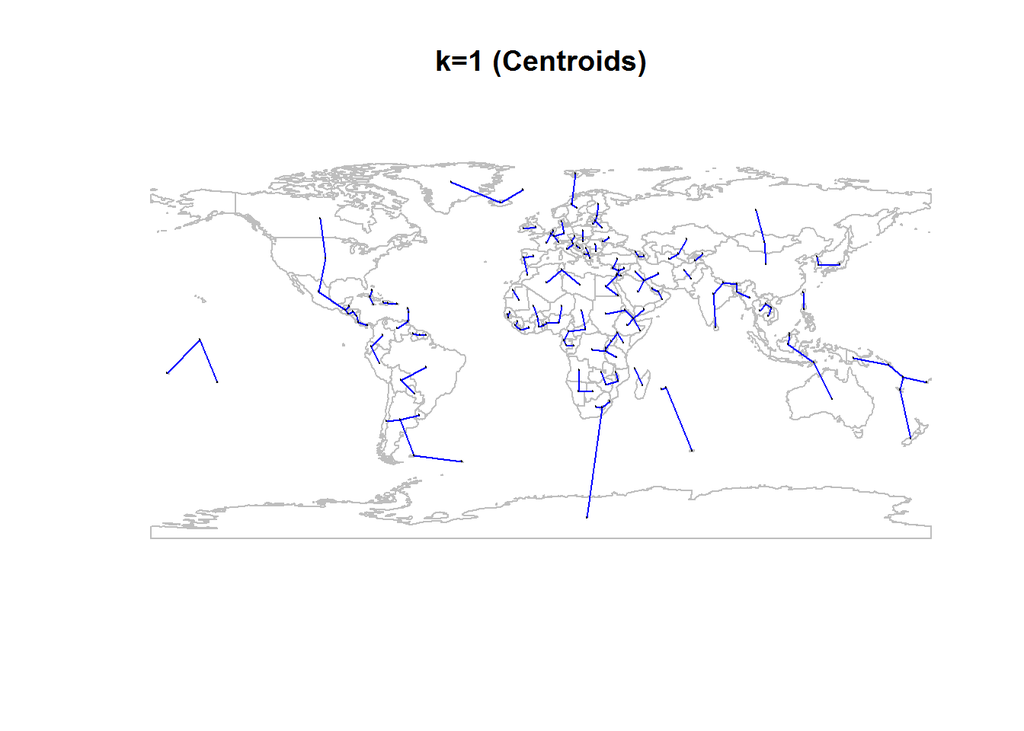

```r
plot(map, border="grey")
plot(W_knn1_mat, coords=map_crd, pch=19, cex=0.1, col="blue", add=TRUE)
title("k=1 (Centroids)")
```

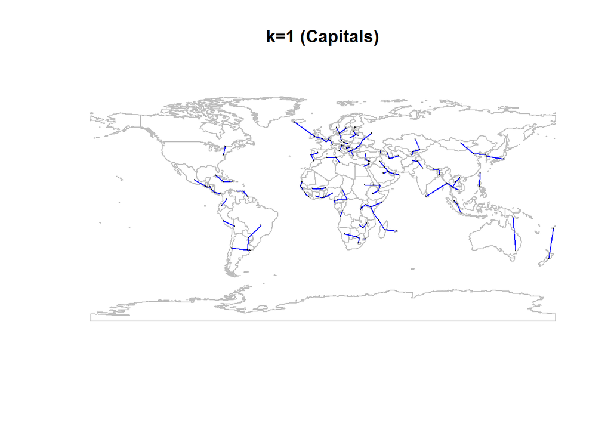

```r
plot(map, border="grey")
plot(W_knn1_mat_2, coords=city_crd, pch=19, cex=0.1, col="blue", add=TRUE)
title("k=1 (Capitals)")
```

Here’s an example of interpoint distance weights (i.e., connections between *all* nearby locations):

```r
# Centroids
dist = unlist(nbdists(W_knn1, map_crd))
W_dist1 = dnearneigh(map_crd, d1=0, d2=max(dist))
W_dist1_mat = nb2listw(W_dist1)

# Capitals
dist_2 = unlist(nbdists(W_knn1_2, city_crd))
W_dist1_2 = dnearneigh(city_crd, d1=0, d2=max(city_crd))
W_dist1_mat_2 = nb2listw(W_dist1_2)
```

Plot the connections!

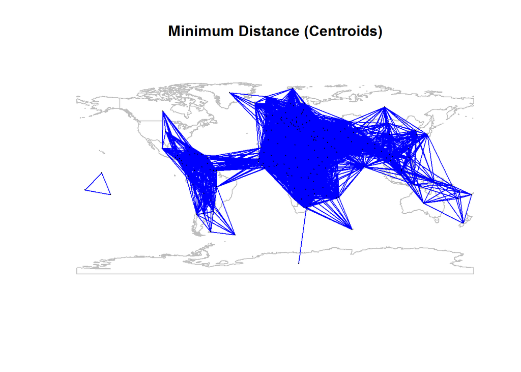

```r
plot(map, border="grey")
plot(W_dist1_mat, coords=map_crd, pch=19, cex=0.1, col="blue", add=TRUE)
title("Minimum Distance (Centroids)")
```

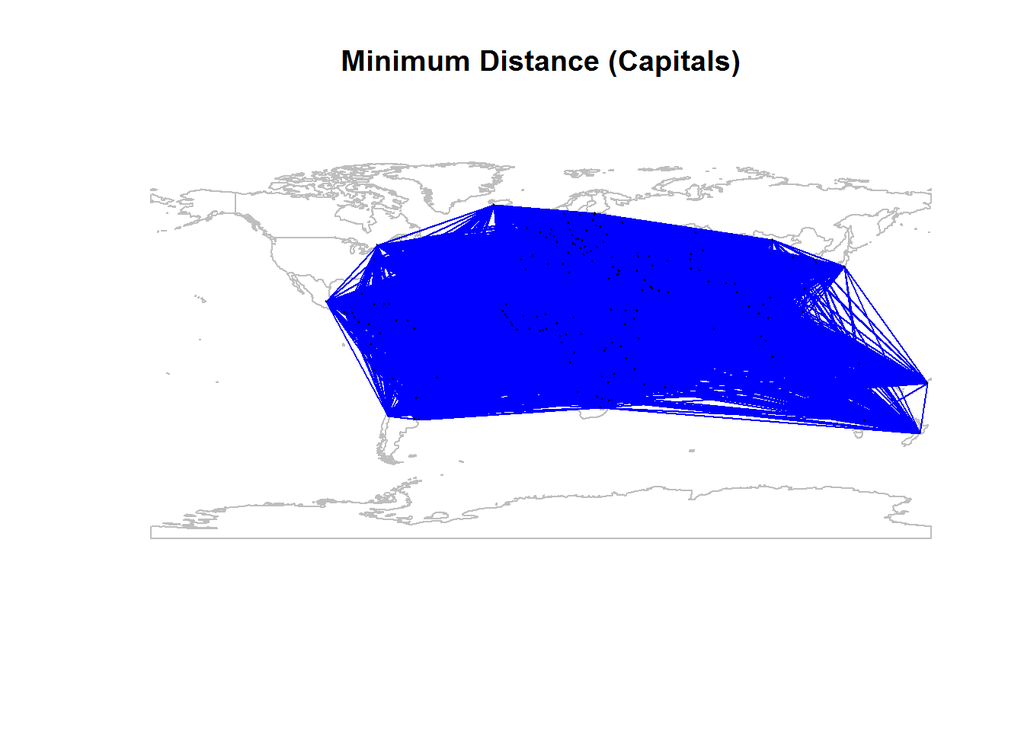

```r
plot(map, border="grey")
plot(W_dist1_mat_2,coords=city_crd, pch=19, cex=0.1, col="blue", add=TRUE)
title("Minimum Distance (Capitals)")
```

What about when $k = 4$?

```r
# Centroids
W_knn4 = knn2nb(knearneigh(map_crd, k=4))
W_knn4_mat = nb2listw(W_knn4)

# Capitals
W_knn4_2 = knn2nb(knearneigh(city_crd, k=4))
W_knn4_mat_2 = nb2listw(W_knn4_2)
```

Plot the connections! Note: We’re just doing this to see what’s going on, this isn’t something we’ll do all the time…

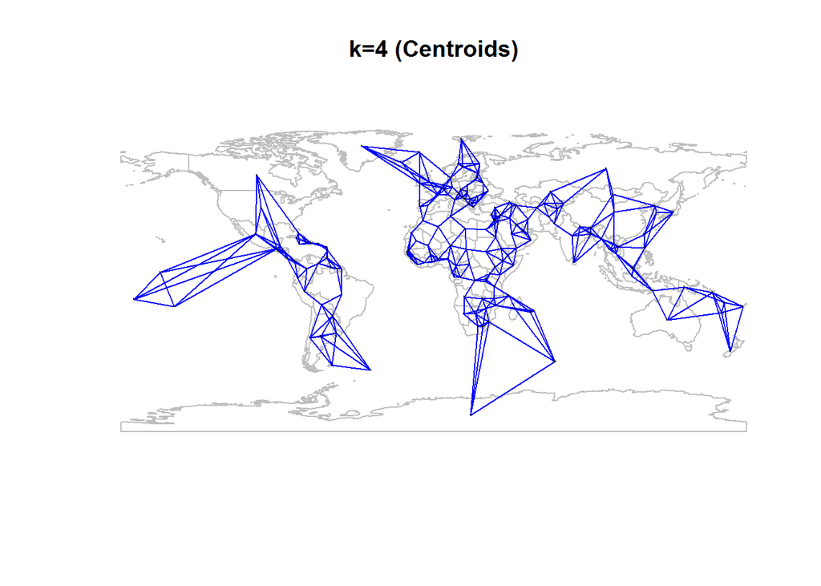

```r
plot(map, border="grey")
plot(W_knn4_mat, coords=map_crd, pch=19, cex=0.1, col="blue", add=TRUE)
title("k=4 (Centroids)")
```

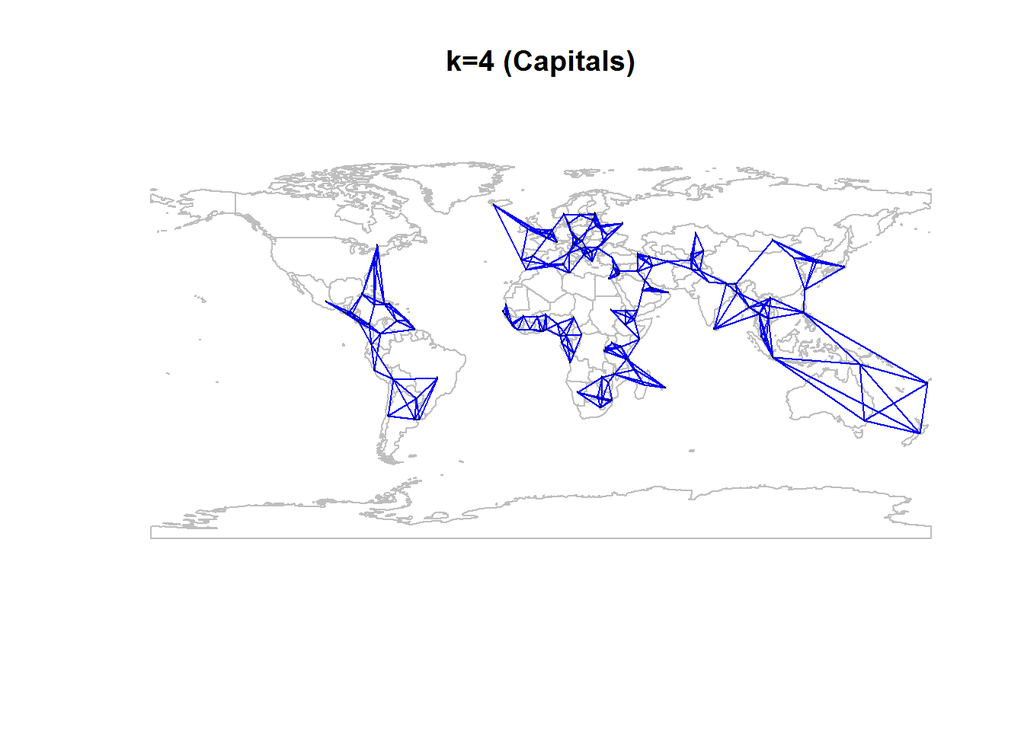

```r
plot(map, border="grey")
plot(W_knn4_mat_2, coords=city_crd, pch=19, cex=0.1, col="blue", add=TRUE)
title("k=4 (Capitals)")
```

### Sphere of Influence

Finally, how about all ‘sphere of influence’ neighbors? I think this one looks the coolest…

```r
# Centroids
W_del = tri2nb(map_crd)
W_soi = graph2nb(soi.graph(W_del, map_crd))
W_soi_mat = nb2listw(W_soi)

# Capitals
W_del_2 = tri2nb(city_crd)
W_soi_2 = graph2nb(soi.graph(W_del_2, city_crd))
W_soi_mat_2 = nb2listw(W_soi_2)
```

Plot the connections!

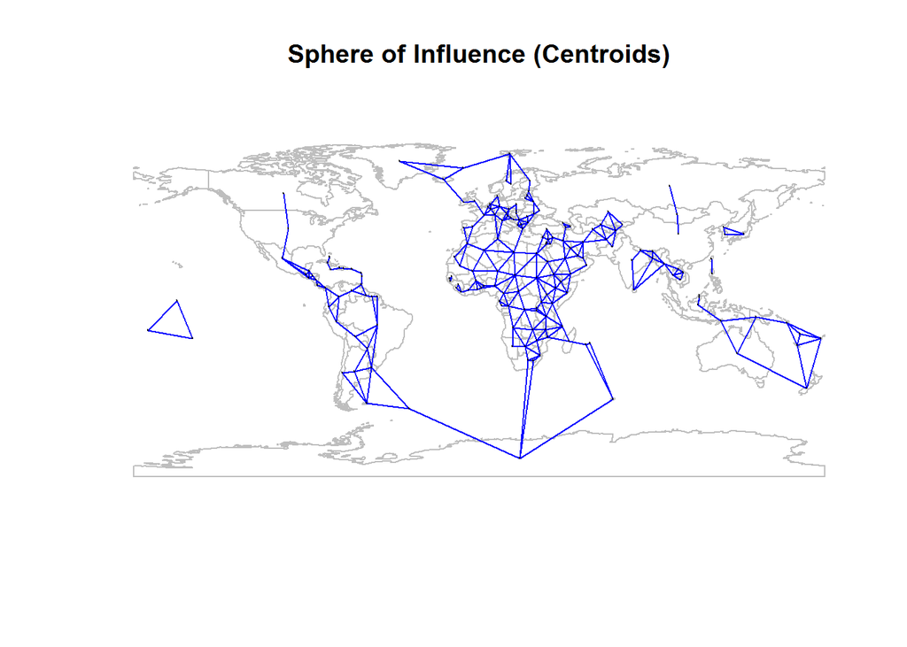

```r
plot(map, border="grey")
plot(W_soi_mat, coords=map_crd, pch=19, cex=0.1, col="blue", add=T)
title("Sphere of Influence (Centroids)")
```

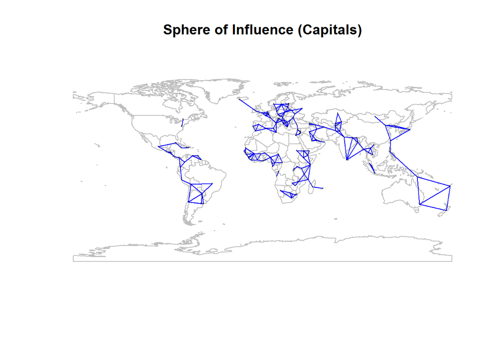

```r
plot(map, border="grey")
plot(W_soi_mat_2, coords=city_crd, pch=19, cex=0.1, col="blue", add=T)
title("Sphere of Influence (Capitals)")
```

# Spatial Autocorrelation

When computing spatial autocorrelation, we could use any one of the above weights definitions. Here we’ll use $k = 4$, and ignore any countries without a polity score:

```r
full = map[!is.na(map$polity),]
full_crd = coordinates(full)
```

Compute the weights matrices

```r
W_knn4 = knn2nb(knearneigh(full_crd, k=4), row.names=full$ccode)
W_knn4_mat = nb2listw(W_knn4)
```

Plot the connections (for fun):

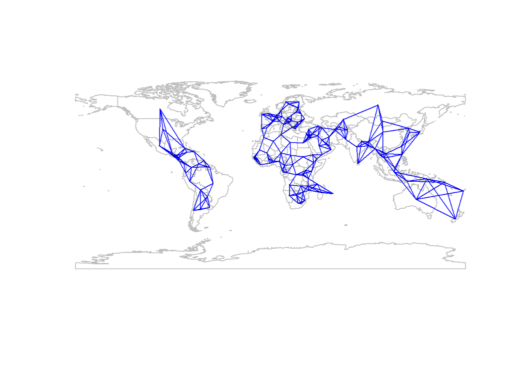

```r
plot(map, border="grey")
plot(W_knn4_mat, coords=full_crd, pch=19, cex=0.1, col="blue", add=TRUE)
```

### Global spatial autocorrelation

We’ll start by exploring Global Autocorrelation Tests. Moran’s I and Geary’s c. Do these two tests confirm one another? I haven’t shown you Geary’s c, so you’ll have to figure out how to do this one your own (and include it in your lab writeup).

```r
moran.test(full$polity, listw=W_knn4_mat, zero.policy=TRUE)
```

```
##
##  Moran I test under randomisation
##
## data:  full$polity
## weights: W_knn4_mat
##
## Moran I statistic standard deviate = 8.1517, p-value < 2.2e-16
## alternative hypothesis: greater
## sample estimates:
## Moran I statistic       Expectation          Variance
##       0.419434756      -0.006535948       0.002730663
```

And now its time to plot the Moran scatterplot. This is a staple of spatial autocorrelation analysis. We’ll talk about this more in class, but really, all we’re doing is plotting a variable, in this case `polity`, against its lagged version (the mean of the `polity` score for the nearest 4 neighbors):

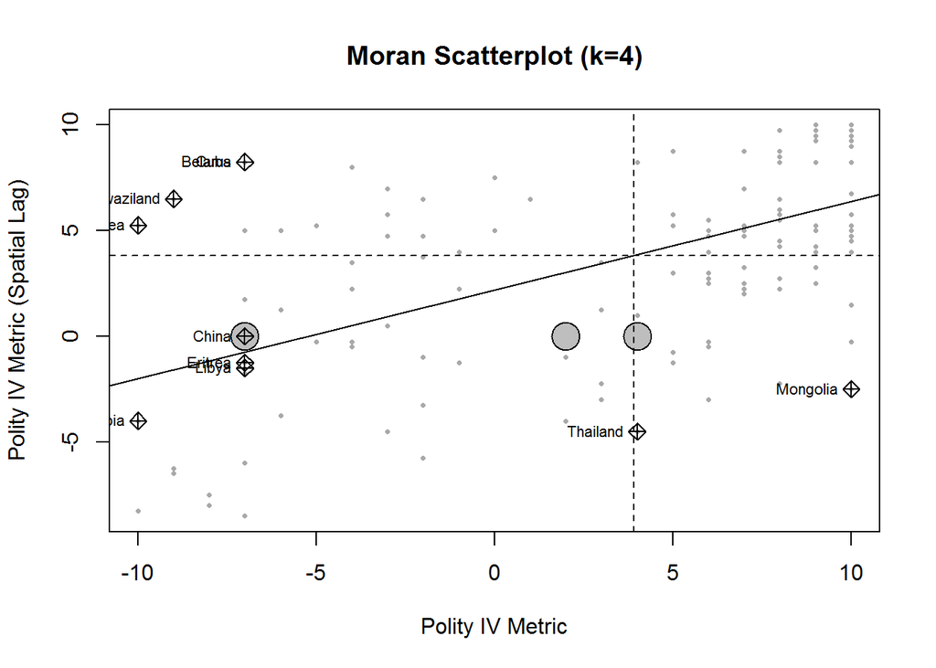

```
## Potentially influential observations of
##   lm(formula = wx ~ x) :
##
##              dfb.1_ dfb.x dffit   cov.r   cook.d hat
## Belarus       0.35  -0.34  0.40_*  0.96    0.08   0.03
## China         0.03  -0.03  0.03    1.04_*  0.00   0.03
## Cuba          0.35  -0.34  0.40_*  0.96    0.08   0.03
## North Korea   0.32  -0.35  0.39_*  1.00    0.07   0.04
## Libya        -0.03   0.03 -0.03    1.04_*  0.00   0.03
## Mongolia     -0.07  -0.19 -0.27    0.95_*  0.03   0.01
## Saudi Arabia -0.09   0.10 -0.11    1.05_*  0.01   0.04
## Swaziland     0.35  -0.37  0.41_*  0.99    0.08   0.03
## Thailand     -0.15   0.00 -0.18    0.96_*  0.02   0.01
## Eritrea      -0.02   0.02 -0.02    1.04_*  0.00   0.03
```

```r
moran.plot(full$polity, listw=W_knn4_mat, zero.policy=TRUE,
           pch=16, col="darkgrey", cex=.5, quiet=FALSE,
           labels=as.character(full$country),
           xlab="Polity IV Metric", ylab="Polity IV Metric (Spatial Lag)",
           main="Moran Scatterplot (k=4)")
```

The slope of the plot (the regression line) gives us a measure of the spatial autocorrelation in the `polity` variable! Very cool!

### Local spatial autocorrelation

Now what about *local* spatial autocorrelation? For now, suffice to say that this is a local measure of spatial autocorrelation that gives us an idea of the level of spatial autocorrelation at each location in the dataset. We’ll spend a lot more time on this in future labs and lectures. For now, we’ll compute the local spatial autocorrelation statistic…

```r
lm1 = localmoran(full$polity, listw=W_knn4_mat, zero.policy=TRUE)
```

and add it to our dataset so that we can map the local levels of ‘clustering’:

```r
# Extract (absolute) z-scores and create new variable `lm1`
full$lm1 = abs(lm1[, "Z.Ii"])
```

Again, since everything has to be a `data.frame` for `ggplot`, we’ll `fortify` the spatial data and add the `full` data attributes back:

```r
# Match up the attributes to the polygons
full@data$id <- as.numeric(rownames(full@data))-1
full.plot = fortify(full)
full.plot = join(full.plot, full@data, by="id")
```

Now we’re able to map the local Moran’s Ii Z-scores:

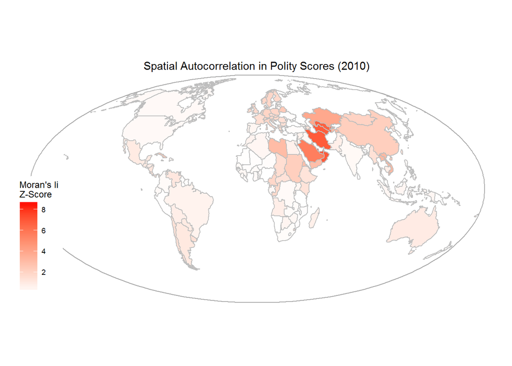

```r
p = ggplot(data=full.plot, aes(long, lat, group=group))

p + geom_polygon(aes(fill=lm1), color="grey") +
    geom_rect(data=outline, aes(xmin=xmin, xmax=xmax, ymin=ymin, ymax=ymax, x=NULL, y=NULL, group=NULL),
              fill="transparent", color="darkgrey") +
    scale_fill_gradient("Moran's Ii\nZ-Score", low="white", high="red") +
    labs(x="Longitude", y="Latitude",
         title="Spatial Autocorrelation in Polity Scores (2010)") +
    coord_map("mollweide") +
    theme_map()
```

# Your turn!

Your lab assignment this week is to perform a similar analysis to the above, this time with one of the datasets available from here:

```r
# Load in a dataset...
load("Data/election.rda")
```

For example, the `election` dataset contains data on the 2004 (Bush vs. Kerry) Presidential elections. Hint: when plotting, the `election` dataset in `ggplot`, you might want to use `coord_map("albers", at0=45.5, lat1=29.5)`, which will plot it using an Albers equal area projection. You could also reproject the whole dataset using `spTranform` to transform it into a projection coordinate system (for better distance calculations).

```r
names(election)
```

```
##  [1] "NAME"       "STATE_NAME" "STATE_FIPS" "CNTY_FIPS"  "FIPS"
##  [6] "AREA"       "FIPS_num"   "Bush"       "Kerry"      "County_F"
## [11] "Nader"      "Total"      "Bush_pct"   "Kerry_pct"  "Nader_pct"
## [16] "MDratio"    "hosp"       "pcthisp"    "pcturban"   "urbrural"
## [21] "pctfemhh"   "pcincome"   "pctpoor"    "pctlt9ed"   "pcthsed"
## [26] "pctcoled"   "unemploy"   "pctwhtcl"   "homevalu"   "rent"
## [31] "popdens"    "crowded"    "ginirev"    "SmokecurM"  "SmokevrM"
## [36] "SmokecurF"  "SmokevrF"   "Obese"      "Noins"      "XYLENES__M"
## [41] "TOLUENE"    "TETRACHLOR" "STYRENE"    "NICKEL_COM" "METHYLENE_"
## [46] "MERCURY_CO" "LEAD_COMPO" "BENZENE__I" "ARSENIC_CO" "POP2000"
## [51] "POP00SQMIL" "MALE2000"   "FEMALE2000" "MAL2FEM"    "UNDER18"
## [56] "AIAN"       "ASIA"       "BLACK"      "NHPI"       "WHITE"
## [61] "AIAN_MORE"  "ASIA_MORE"  "BLK_MORE"   "NHPI_MORE"  "WHT_MORE"
## [66] "HISP_LAT"   "CH19902000" "MEDAGE2000" "PEROVER65"
```

Specifically, I want you to include all `R` code and outputs you create to repeat the **analytical steps shown in the `Spatial Autocorrelation` section of this handout**:

- Build a contiguity matrix that you think meaningfully describes relationships in your dataset.
- Compute global spatial autocorrelation statistics (Moran’s I and Geary’s C) and interpret these.
- Compute local spatial autocorrelation statistics (Local Moran’s I and Geary ci) - interpret patterns you see.

You should **interpret the output from the Global spatial autocorrelation analyses** (both! also try join counts if you can figure out how to create a categorical varable), and also talk briefly about your local spatial autocorrelation maps (Hint: you can also try plotting those using the actual values (not absolute) using a diverging color scheme). Also, think clearly about what spatial weights definition you use and why (you can come up with something I’m sure). **Plot the connections** to give us an idea of **how you conceptualized ‘near’**.

The main goal here is to get you ‘playing’ with spatial data in `R`, and to become familiar with spatial weights, plotting, and spatial autocorrelation. For bonus points, you could try to fit a model using one of the datasets and then computing spatial autocorrelation statistics on the residuals. What does this show you?